# Celiac Disease Lab Data — EDA + Modeling

## Project Overview

The goal of this project is to explore and model laboratory and clinical data related to celiac disease. Using a Kaggle dataset, the following steps were performed:

- Exploratory data analysis (EDA)
- Feature engineering and data cleaning
- Dimensionality reduction (PCA)
- Supervised learning using:
  - Decision trees (C5.0)
  - k-nearest neighbors (KNN)
  - Random forest

A key clinical motivation is minimizing **false negatives**, since missing a true celiac diagnosis may lead to delayed treatment and long-term complications.

All three models are trained and scored on the **same train/test split** and the **same predictors**, so the comparison at the end reflects model choice rather than differences in setup. Hyperparameters are chosen by repeated cross-validation on the training set, the test set is evaluated exactly once, and the differences between models are checked for significance rather than assumed.

The report closes by asking what these models would actually do at real-world celiac prevalence — which turns out to matter more than any accuracy figure in it.

## Data Source

The dataset was obtained from Kaggle: **Celiac Disease Lab Data** — https://www.kaggle.com/datasets/jackwin07/celiac-disease-coeliac-disease

To ensure balanced class representation, the dataset was shuffled and subsampled to include an equal number of diagnosed and non-diagnosed individuals (363 each, n = 726). That processed file is committed as `data/shuffled_data.csv`; the exact preparation steps are recorded in `data/README.md`.

```r
celiac_data <- read.csv("data/shuffled_data.csv")
head(celiac_data, 10)
```

```
##    Age Gender Diabetes Diabetes.Type    Diarrhoea Abdominal Short_Stature
## 1   10 Female       no            NA       fatty         no           DSS
## 2    7   Male       no            NA       watery        no      Variant
## 3    7   Male      Yes             1 inflammatory       yes           PSS
## 4   18   Male      Yes             1       fatty        yes      Variant
## 5    3   Male      Yes             1 inflammatory       yes      Variant
## 6   14   Male       no            NA       watery       yes           DSS
## 7    8   Male      Yes             1       fatty        yes           PSS
## 8   28 Female      Yes             1       watery       yes      Variant
## 9   13 Female      Yes             1       fatty        yes      Variant
## 10  10 Female       no            NA       watery        no           DSS
##    Sticky_Stool Weight_loss  IgA  IgG  IgM Marsh   cd_type Disease_Diagnose
## 1            no          no 1.30  8.0 1.00     0      none               no
## 2            no          no 1.00  5.0 1.20     0      none               no
## 3           yes         yes 0.92 12.0 1.00     0      none               no
## 4           yes         yes 2.10 12.3 0.98     0      none               no
## 5           yes         yes 1.00  9.0 1.40     1 potential              yes
## 6           yes          no 9.00 12.0 1.70     0      none               no
## 7           yes         yes 2.10 11.4 1.00     0      none               no
## 8           yes          no 1.00 11.0 1.00     0      none               no
## 9           yes         yes 0.90  8.0 1.00     0    latent              yes
## 10           no          no 1.30  8.0 1.00     0      none               no
```

## The features

- **PSS / DSS** — types of growth delay. PSS is proportionate, DSS is not.
- **IgA, IgG, IgM** — immunoglobulin antibodies in the blood. Elevated levels mean the immune system is engaged.
- **Marsh** — doctors use Marsh scores to quantify damage to the small intestine from celiac disease. The score reflects how much the intestinal villi have been damaged.
- **cd_type** — the clinical subtype of celiac disease.

```r
summary(celiac_data)
```

```
##       Age           Gender            Diabetes         Diabetes.Type
##  Min.   : 3.00   Length:726         Length:726         Min.   :1.000
##  1st Qu.: 8.00   Class :character   Class :character   1st Qu.:1.000
##  Median :10.00   Mode  :character   Mode  :character   Median :1.000
##  Mean   :11.78                                         Mean   :1.056
##  3rd Qu.:14.00                                         3rd Qu.:1.000
##  Max.   :35.00                                         Max.   :2.000
##                                                        NA's   :317
##   Diarrhoea          Abdominal         Short_Stature      Sticky_Stool
##  Length:726         Length:726         Length:726         Length:726
##  Class :character   Class :character   Class :character   Class :character
##  Mode  :character   Mode  :character   Mode  :character   Mode  :character
##
##
##
##
##  Weight_loss             IgA             IgG              IgM
##  Length:726         Min.   :0.340   Min.   : 5.000   Min.   :0.600
##  Class :character   1st Qu.:1.000   1st Qu.: 8.500   1st Qu.:1.000
##  Mode  :character   Median :1.200   Median : 9.500   Median :1.100
##                     Mean   :1.666   Mean   : 9.891   Mean   :1.258
##                     3rd Qu.:1.900   3rd Qu.:12.000   3rd Qu.:1.600
##                     Max.   :9.000   Max.   :14.200   Max.   :2.300
##
##     Marsh             cd_type          Disease_Diagnose
##  Length:726         Length:726         Length:726
##  Class :character   Class :character   Class :character
##  Mode  :character   Mode  :character   Mode  :character
##
##
##
##
```

## Target Variable

The target `Disease_Diagnose` indicates whether a patient has been diagnosed with celiac disease. It is converted to a factor for classification.

```r
celiac_data$Disease_Diagnose <- as.factor(celiac_data$Disease_Diagnose)
table(celiac_data$Disease_Diagnose)
```

```
##
##  no yes
## 363 363
```

## Distribution of Numeric Features

Histograms help identify outliers and scale differences between features.

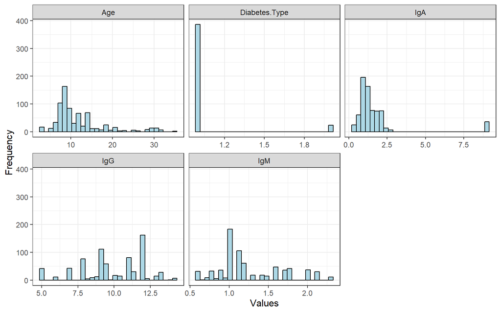

```r
celiac_data %>%
  select(where(is.numeric)) %>%
  gather(attributes, value) %>%
  ggplot(aes(x = value)) +
  geom_histogram(fill = "lightblue", color = "black", bins = 30) +
  facet_wrap(~attributes, scales = "free_x") +
  labs(x = "Values", y = "Frequency") +
  theme_bw()
```

Observations:

- Diabetes type is almost entirely type 1.
- There is little spread in the IgA values.
- Most patients are relatively young — roughly 1–15 years old.

## Clinical Subtypes of Celiac Disease

`cd_type` records the clinical subtype. Only diagnosed patients have a subtype, so `none` is excluded here.

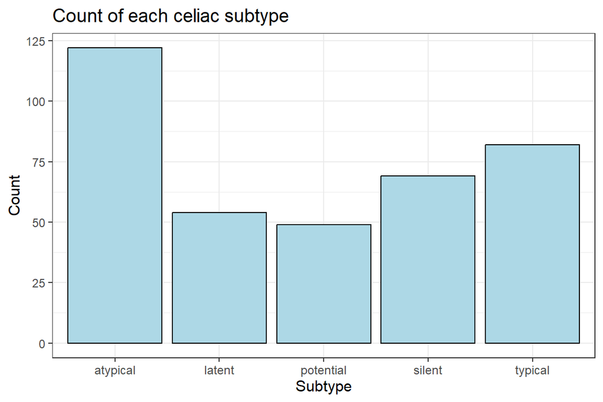

```r
cd_type_only <- subset(celiac_data, cd_type != "none")

ggplot(cd_type_only, aes(x = cd_type)) +
  geom_bar(fill = "lightblue", color = "black") +
  labs(x = "Subtype", y = "Count", title = "Count of each celiac subtype") +
  theme_bw()
```

```r
round(prop.table(table(cd_type_only$cd_type)) * 100, 1)
```

```
##
##  atypical    latent potential    silent   typical
##      32.4      14.4      13.0      18.4      21.8
```

## Feature Engineering

To prepare the data for modeling:

- Marsh scores were converted to numeric form (`3a` → `3.1`, `3b` → `3.2`, `3c` → `3.3`)
- Binary clinical symptoms were encoded as 0/1
- Gender and diagnosis were binarised
- Columns with extensive missing values or redundant information were excluded

```r
numeric_celiac_data <- celiac_data

numeric_celiac_data$Marsh <- gsub("a", ".1", numeric_celiac_data$Marsh)
numeric_celiac_data$Marsh <- gsub("b", ".2", numeric_celiac_data$Marsh)
numeric_celiac_data$Marsh <- gsub("c", ".3", numeric_celiac_data$Marsh)
numeric_celiac_data$Marsh <- as.numeric(numeric_celiac_data$Marsh)

numeric_celiac_data$Diabetes         <- ifelse(numeric_celiac_data$Diabetes == "Yes", 1, 0)
numeric_celiac_data$Abdominal        <- ifelse(numeric_celiac_data$Abdominal == "yes", 1, 0)
numeric_celiac_data$Sticky_Stool     <- ifelse(numeric_celiac_data$Sticky_Stool == "yes", 1, 0)
numeric_celiac_data$Weight_loss      <- ifelse(numeric_celiac_data$Weight_loss == "yes", 1, 0)
numeric_celiac_data$Gender           <- ifelse(numeric_celiac_data$Gender == "Female", 1, 0)
numeric_celiac_data$Disease_Diagnose <- ifelse(numeric_celiac_data$Disease_Diagnose == "yes", 1, 0)

head(numeric_celiac_data, 10)
```

```
##    Age Gender Diabetes Diabetes.Type    Diarrhoea Abdominal Short_Stature
## 1   10      1        0            NA       fatty          0           DSS
## 2    7      0        0            NA       watery         0      Variant
## 3    7      0        1             1 inflammatory         1           PSS
## 4   18      0        1             1       fatty          1      Variant
## 5    3      0        1             1 inflammatory         1      Variant
## 6   14      0        0            NA       watery         1           DSS
## 7    8      0        1             1       fatty          1           PSS
## 8   28      1        1             1       watery         1      Variant
## 9   13      1        1             1       fatty          1      Variant
## 10  10      1        0            NA       watery         0           DSS
##    Sticky_Stool Weight_loss  IgA  IgG  IgM Marsh   cd_type Disease_Diagnose
## 1             0           0 1.30  8.0 1.00     0      none                0
## 2             0           0 1.00  5.0 1.20     0      none                0
## 3             1           1 0.92 12.0 1.00     0      none                0
## 4             1           1 2.10 12.3 0.98     0      none                0
## 5             1           1 1.00  9.0 1.40     1 potential                1
## 6             1           0 9.00 12.0 1.70     0      none                0
## 7             1           1 2.10 11.4 1.00     0      none                0
## 8             1           0 1.00 11.0 1.00     0      none                0
## 9             1           1 0.90  8.0 1.00     0    latent                1
## 10            0           0 1.30  8.0 1.00     0      none                0
```

### Choosing one predictor set

Every model below uses the same ten predictors. Three columns are dropped:

- **`cd_type`** — only diagnosed patients have a subtype, so it encodes the label directly.
- **`Diabetes.Type`** — `NA` for every non-diabetic patient and almost always `1` otherwise, so it adds no information beyond `Diabetes`.
- **`Diarrhoea`, `Short_Stature`** — multi-class categorical. KNN needs numeric input, and using them for the tree but not for KNN would make the model comparison unfair.

```r
PREDICTORS <- c("Age", "Gender", "Diabetes", "Abdominal", "Sticky_Stool",
                "Weight_loss", "IgA", "IgG", "IgM", "Marsh")

model_data <- numeric_celiac_data %>%
  select(all_of(PREDICTORS), Disease_Diagnose) %>%
  mutate(Disease_Diagnose = factor(Disease_Diagnose,
                                   levels = c(0, 1),
                                   labels = c("healthy", "sick")))

str(model_data)
```

```
## 'data.frame':    726 obs. of  11 variables:
##  $ Age             : int  10 7 7 18 3 14 8 28 13 10 ...
##  $ Gender          : num  1 0 0 0 0 0 0 1 1 1 ...
##  $ Diabetes        : num  0 0 1 1 1 0 1 1 1 0 ...
##  $ Abdominal       : num  0 0 1 1 1 1 1 1 1 0 ...
##  $ Sticky_Stool    : num  0 0 1 1 1 1 1 1 1 0 ...
##  $ Weight_loss     : num  0 0 1 1 1 0 1 0 1 0 ...
##  $ IgA             : num  1.3 1 0.92 2.1 1 9 2.1 1 0.9 1.3 ...
##  $ IgG             : num  8 5 12 12.3 9 12 11.4 11 8 8 ...
##  $ IgM             : num  1 1.2 1 0.98 1.4 1.7 1 1 1 1 ...
##  $ Marsh           : num  0 0 0 0 1 0 0 0 0 0 ...
##  $ Disease_Diagnose: Factor w/ 2 levels "healthy","sick": 1 1 1 1 2 1 1 1 2 1 ...
```

## Feature Correlation Analysis

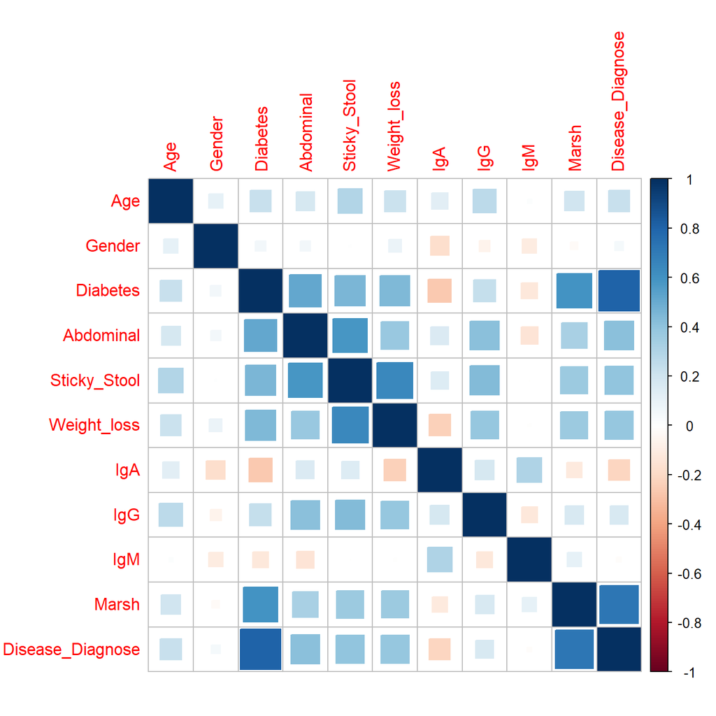

```r
cor_data <- model_data %>%
  mutate(Disease_Diagnose = as.numeric(Disease_Diagnose) - 1) %>%
  cor()

corrplot(cor_data, method = "square")
```

As anticipated, most of the stomach-related symptoms are correlated with each other. The two features most correlated with the diagnosis are **Marsh** and **Diabetes**. Abdominal pain, sticky stool and weight loss also show correlation with the target.

The correlation between diabetes and the stomach symptoms prompted a check of the literature, to rule out that these symptoms come from diabetes rather than from celiac disease.

> **Note on `Marsh`.** The Marsh score is the histological grading used to *make* the celiac diagnosis in the first place. Its strong correlation with the target is therefore partly circular. It is kept in the main models as the strongest available predictor, but a model fitted without it appears at the end of the report.

## Dimensionality Reduction (PCA)

PCA is used to visualise separation between healthy and sick individuals. The features are on very different scales — `Age` spans decades while most symptoms are 0/1 — so the data is **scaled** before decomposition. Without scaling, the first component would simply track `Age`.

```r
pca_fit <- prcomp(model_data[, PREDICTORS], scale. = TRUE)

pct_var <- round(100 * summary(pca_fit)$importance[2, 1:2], 1)
pct_var
```

```
##  PC1  PC2
## 32.7 15.6
```

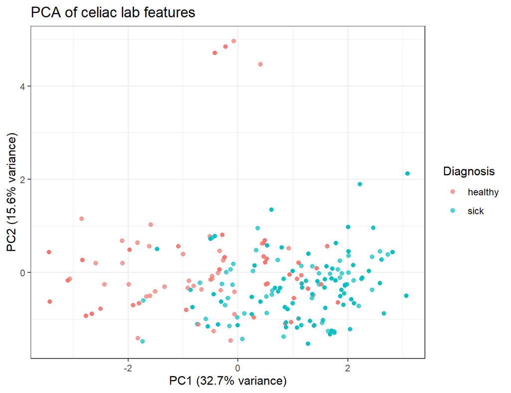

```r
pca_df <- data.frame(
  PC1 = pca_fit$x[, 1],
  PC2 = pca_fit$x[, 2],
  Diagnosis = model_data$Disease_Diagnose,
  Subtype   = celiac_data$cd_type
)

ggplot(pca_df, aes(x = PC1, y = PC2, colour = Diagnosis)) +
  geom_point(alpha = 0.7) +
  labs(
    title = "PCA of celiac lab features",
    x = paste0("PC1 (", pct_var[1], "% variance)"),
    y = paste0("PC2 (", pct_var[2], "% variance)")
  ) +
  theme_bw()
```

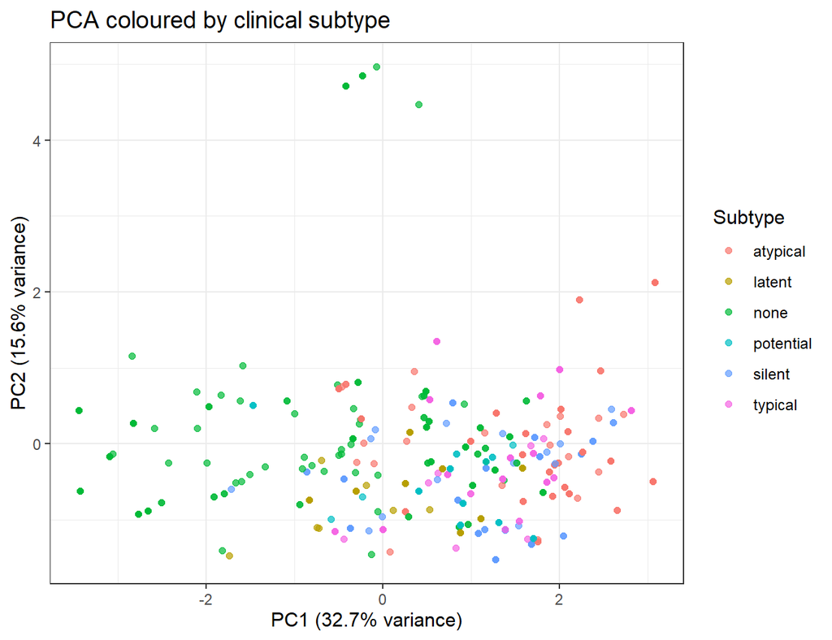

```r
ggplot(pca_df, aes(x = PC1, y = PC2, colour = Subtype)) +
  geom_point(alpha = 0.7) +
  labs(
    title = "PCA coloured by clinical subtype",
    x = paste0("PC1 (", pct_var[1], "% variance)"),
    y = paste0("PC2 (", pct_var[2], "% variance)")
  ) +
  theme_bw()
```

## One Shared Train/Test Split

The split is created **once** here and reused by all three models, so the comparison at the end is apples-to-apples.

```r
set.seed(1234)

n_total <- nrow(model_data)
train_idx <- sample(n_total, round(0.8 * n_total))

train_raw <- model_data[train_idx, ]
test_raw  <- model_data[-train_idx, ]

train_labels <- train_raw$Disease_Diagnose
test_labels  <- test_raw$Disease_Diagnose

# sanity check: the split must be disjoint and cover every row
stopifnot(
  length(intersect(train_idx, seq_len(n_total)[-train_idx])) == 0,
  nrow(train_raw) + nrow(test_raw) == n_total
)

c(train = nrow(train_raw), test = nrow(test_raw))
```

```
## train  test
##   581   145
```

```r
rbind(
  train = prop.table(table(train_raw$Disease_Diagnose)),
  test  = prop.table(table(test_raw$Disease_Diagnose))
)
```

```
##         healthy      sick
## train 0.5215146 0.4784854
## test  0.4137931 0.5862069
```

### Normalisation fitted on the training set only

KNN is distance-based, so features must be on a common scale. The min and max are computed from the **training rows only** and then applied to the test rows — computing them over the full dataset would leak information about the test set into the model.

Test values may therefore fall slightly outside `[0, 1]`; that is expected and correct.

```r
train_min <- sapply(train_raw[, PREDICTORS], min)
train_max <- sapply(train_raw[, PREDICTORS], max)

apply_minmax <- function(df) {
  as.data.frame(scale(df[, PREDICTORS],
                      center = train_min,
                      scale  = train_max - train_min))
}

train_norm <- apply_minmax(train_raw)
test_norm  <- apply_minmax(test_raw)

range(test_norm)
```

```
## [1] 0 1
```

Decision trees and random forests split on thresholds, so they are unaffected by any monotone rescaling. They are fitted on the unnormalised features; only KNN uses `train_norm` / `test_norm`.

### A shared evaluation helper

Every model is scored with the same function, so the summary table at the end is consistent.

```r
CLASSES <- c("healthy", "sick")

# forcing the levels keeps the matrix 2x2 even if a model never predicts one class
confusion <- function(truth, pred) {
  table(Predicted = factor(pred,  levels = CLASSES),
        Actual    = factor(truth, levels = CLASSES))
}

eval_model <- function(name, truth, pred) {
  cm <- confusion(truth, pred)
  tibble(
    Model             = name,
    Accuracy          = sum(diag(cm)) / sum(cm),
    Sensitivity       = cm["sick", "sick"] / sum(cm[, "sick"]),
    Specificity       = cm["healthy", "healthy"] / sum(cm[, "healthy"]),
    `False negatives` = cm["healthy", "sick"],
    `False positives` = cm["sick", "healthy"]
  )
}
```

## Model Selection by Cross-Validation

The hyperparameters below — `k` for KNN, `mtry` for the forest, and the false-negative cost ratio for C5.0 — were originally chosen by hand. Here they are selected properly, by **repeated 10-fold cross-validation on the training set only**. The test set is not touched until the final comparison.

```r
set.seed(2024)
folds <- vfold_cv(train_raw, v = 10, repeats = 5, strata = Disease_Diagnose)

nrow(folds)  # 10 folds x 5 repeats
```

```
## [1] 50
```

Each candidate is scored with the same loop. Note that the min-max scaler for KNN is refitted **inside every fold** from that fold’s analysis rows — doing it once outside would leak the assessment rows’ range into training, which is the bug this report fixed earlier. Putting it inside the loop makes that mistake structurally impossible to reintroduce.

```r
cv_evaluate <- function(fit_predict) {
  map_dfr(seq_len(nrow(folds)), function(i) {
    sp <- folds$splits[[i]]
    tr <- analysis(sp)
    te <- assessment(sp)

    cm <- confusion(te$Disease_Diagnose, fit_predict(tr, te))

    tibble(
      accuracy = sum(diag(cm)) / sum(cm),
      sens     = cm["sick", "sick"] / sum(cm[, "sick"]),
      fn       = cm["healthy", "sick"]
    )
  })
}

# mean and standard error across the 50 resamples
cv_summarise <- function(res, label) {
  res %>% summarise(
    Setting     = label,
    Accuracy    = mean(accuracy),
    `Std error` = sd(accuracy) / sqrt(n()),
    Sensitivity = mean(sens),
    `Mean FN`   = mean(fn)
  )
}
```

### Tuning `k` for KNN

```r
k_grid <- seq(1, 25, by = 2)

knn_cv <- map_dfr(k_grid, function(k) {
  cv_evaluate(function(tr, te) {
    lo <- sapply(tr[, PREDICTORS], min)
    hi <- sapply(tr[, PREDICTORS], max)
    rng <- ifelse(hi - lo == 0, 1, hi - lo)     # guard against constant columns

    tr_n <- scale(tr[, PREDICTORS], center = lo, scale = rng)
    te_n <- scale(te[, PREDICTORS], center = lo, scale = rng)

    knn(train = tr_n, test = te_n, cl = tr$Disease_Diagnose, k = k)
  }) %>% cv_summarise(k)
})

best_k <- knn_cv$Setting[which.max(knn_cv$Accuracy)]
knn_cv
```

```
## # A tibble: 13 × 5
##    Setting Accuracy `Std error` Sensitivity `Mean FN`
##      <dbl>    <dbl>       <dbl>       <dbl>     <dbl>
##  1       1    0.940     0.00419       0.937      1.74
##  2       3    0.927     0.00452       0.917      2.3
##  3       5    0.921     0.00510       0.925      2.1
##  4       7    0.924     0.00512       0.945      1.52
##  5       9    0.929     0.00494       0.958      1.18
##  6      11    0.925     0.00534       0.951      1.36
##  7      13    0.920     0.00553       0.943      1.58
##  8      15    0.924     0.00555       0.942      1.6
##  9      17    0.927     0.00514       0.943      1.58
## 10      19    0.925     0.00536       0.940      1.66
## 11      21    0.922     0.00548       0.937      1.74
## 12      23    0.921     0.00524       0.940      1.68
## 13      25    0.923     0.00497       0.944      1.56
```

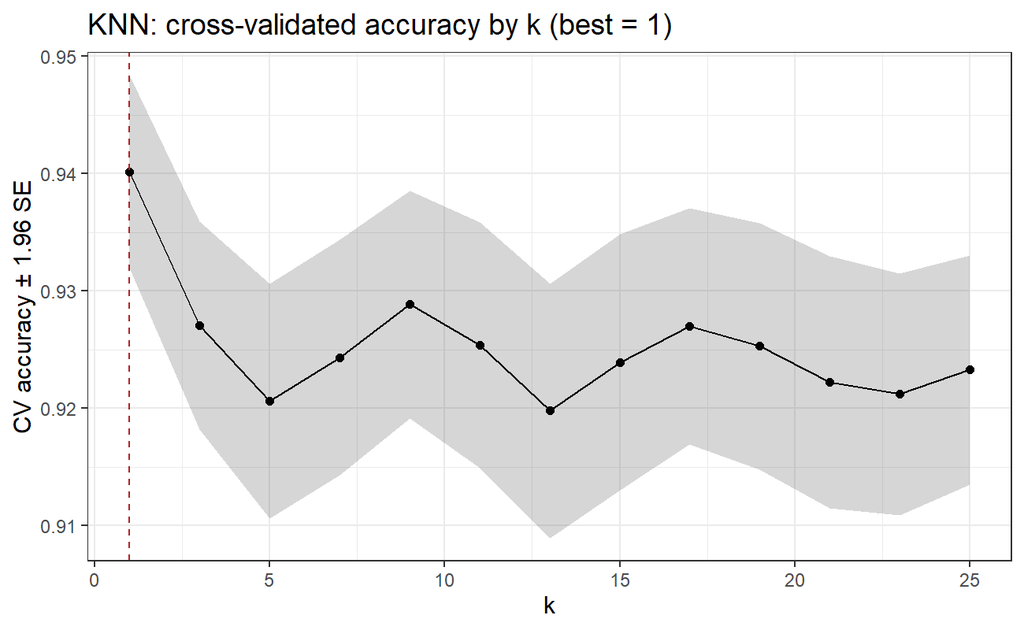

```r
ggplot(knn_cv, aes(x = Setting, y = Accuracy)) +
  geom_ribbon(aes(ymin = Accuracy - 1.96 * `Std error`,
                  ymax = Accuracy + 1.96 * `Std error`), alpha = 0.2) +
  geom_line() + geom_point() +
  geom_vline(xintercept = best_k, linetype = "dashed", colour = "firebrick") +
  labs(title = paste0("KNN: cross-validated accuracy by k (best = ", best_k, ")"),
       x = "k", y = "CV accuracy ± 1.96 SE") +
  theme_bw()
```

### Tuning `mtry` for the random forest

```r
mtry_grid <- 1:6

rf_cv <- map_dfr(mtry_grid, function(m) {
  cv_evaluate(function(tr, te) {
    fit <- ranger::ranger(Disease_Diagnose ~ ., data = tr[, c(PREDICTORS, "Disease_Diagnose")],
                          num.trees = 500, mtry = m, seed = 234)
    predict(fit, te)$predictions
  }) %>% cv_summarise(m)
})

best_mtry <- rf_cv$Setting[which.max(rf_cv$Accuracy)]
rf_cv
```

```
## # A tibble: 6 × 5
##   Setting Accuracy `Std error` Sensitivity `Mean FN`
##     <int>    <dbl>       <dbl>       <dbl>     <dbl>
## 1       1    0.930     0.00417       0.978      0.6
## 2       2    0.962     0.00355       0.972      0.78
## 3       3    0.962     0.00305       0.968      0.9
## 4       4    0.962     0.00310       0.967      0.92
## 5       5    0.964     0.00309       0.969      0.86
## 6       6    0.964     0.00309       0.968      0.88
```

### Tuning the C5.0 false-negative cost ratio

Accuracy is the wrong objective here — the point of the cost matrix is to trade false positives for false negatives, so the ratio is chosen on **mean false negatives per fold**, with accuracy reported alongside to show what that costs.

```r
cost_grid <- c(1, 2, 3, 5, 10)

cost_cv <- map_dfr(cost_grid, function(r) {
  cv_evaluate(function(tr, te) {
    costs <- matrix(c(0, r, 1, 0), nrow = 2,
                    dimnames = list(actual = CLASSES, predicted = CLASSES))
    fit <- C5.0(tr[, PREDICTORS], tr$Disease_Diagnose, trials = 10, costs = costs)
    predict(fit, te)
  }) %>% cv_summarise(r)
})

best_cost <- cost_cv$Setting[which.min(cost_cv$`Mean FN`)]
cost_cv
```

```
## # A tibble: 5 × 5
##   Setting Accuracy `Std error` Sensitivity `Mean FN`
##     <dbl>    <dbl>       <dbl>       <dbl>     <dbl>
## 1       1    0.964     0.00372       0.960      1.1
## 2       2    0.965     0.00343       0.978      0.6
## 3       3    0.968     0.00327       0.983      0.46
## 4       5    0.966     0.00360       0.986      0.4
## 5      10    0.957     0.00342       0.990      0.28
```

The trade-off is visible in the table: false negatives fall steadily as the ratio rises, while accuracy peaks around 3 and then declines. Selecting on false negatives picks the most aggressive ratio and knowingly gives up about a point of accuracy — which is the entire point of using a cost matrix.

```r
tibble(
  Parameter = c("KNN k", "Forest mtry", "C5.0 cost ratio"),
  Selected  = c(best_k, best_mtry, best_cost)
)
```

```
## # A tibble: 3 × 2
##   Parameter       Selected
##   <chr>              <dbl>
## 1 KNN k                  1
## 2 Forest mtry            5
## 3 C5.0 cost ratio       10
```

These selected values are used for every model fitted below.

## Decision Tree (C5.0)

```r
celiac_model <- C5.0(train_raw[, PREDICTORS], train_labels)
celiac_prediction <- predict(celiac_model, test_raw)

CrossTable(test_labels, celiac_prediction,
           prop.chisq = FALSE, prop.c = FALSE, prop.r = FALSE,
           dnn = c("actual", "predicted"))
```

```
##
##
##    Cell Contents
## |-------------------------|
## |                       N |
## |         N / Table Total |
## |-------------------------|
##
##
## Total Observations in Table:  145
##
##
##              | predicted
##       actual |   healthy |      sick | Row Total |
## -------------|-----------|-----------|-----------|
##      healthy |        58 |         2 |        60 |
##              |     0.400 |     0.014 |           |
## -------------|-----------|-----------|-----------|
##         sick |         5 |        80 |        85 |
##              |     0.034 |     0.552 |           |
## -------------|-----------|-----------|-----------|
## Column Total |        63 |        82 |       145 |
## -------------|-----------|-----------|-----------|
##
##
```

### Boosting

```r
celiac_boost10 <- C5.0(train_raw[, PREDICTORS], train_labels,
                       trials = 10, control = C5.0Control(CF = 0.2))

celiac_boost_pred10 <- predict(celiac_boost10, test_raw)

CrossTable(test_labels, celiac_boost_pred10,
           prop.chisq = FALSE, prop.c = FALSE, prop.r = FALSE,
           dnn = c("actual", "predicted"))
```

```
##
##
##    Cell Contents
## |-------------------------|
## |                       N |
## |         N / Table Total |
## |-------------------------|
##
##
## Total Observations in Table:  145
##
##
##              | predicted
##       actual |   healthy |      sick | Row Total |
## -------------|-----------|-----------|-----------|
##      healthy |        57 |         3 |        60 |
##              |     0.393 |     0.021 |           |
## -------------|-----------|-----------|-----------|
##         sick |         5 |        80 |        85 |
##              |     0.034 |     0.552 |           |
## -------------|-----------|-----------|-----------|
## Column Total |        62 |        83 |       145 |
## -------------|-----------|-----------|-----------|
##
##
```

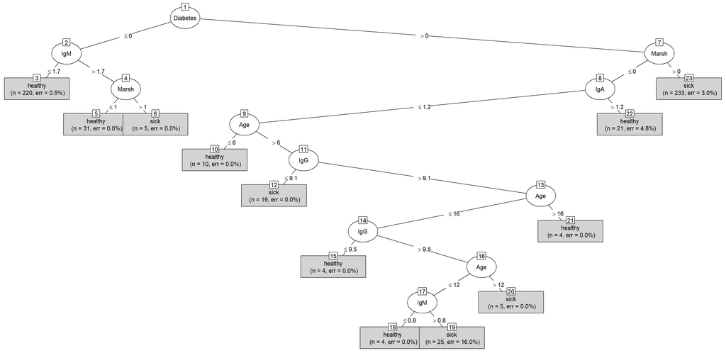

```r
plot(celiac_boost10, type = "simple", trial = 0)
```

### Adding a cost matrix

**Watch the orientation.** `C5.0()` expects the cost matrix indexed as `[actual, predicted]` — rows are the true class, columns are the predicted one. Several textbook examples label the dimensions the other way round, and since the labels are only cosmetic, a transposed matrix fails silently: it penalises false *positives* while appearing to penalise false negatives. Here that would push false negatives up rather than down.

The false-negative cell is therefore *actual = sick, predicted = healthy*, i.e. row `sick`, column `healthy`.

```r
matrix_dimensions <- list(actual = CLASSES, predicted = CLASSES)

# column-major fill puts best_cost at [sick, healthy] = actual sick, predicted healthy = false negative
error_cost <- matrix(c(0, best_cost, 1, 0), nrow = 2, dimnames = matrix_dimensions)
error_cost
```

```
##          predicted
## actual    healthy sick
##   healthy       0    1
##   sick         10    0
```

```r
celiac_cost_10 <- C5.0(train_raw[, PREDICTORS], train_labels,
                       trials = 10, costs = error_cost)

celiac_cost_pred <- predict(celiac_cost_10, test_raw)

CrossTable(test_labels, celiac_cost_pred,
           prop.chisq = FALSE, prop.c = FALSE, prop.r = FALSE,
           dnn = c("actual", "predicted"))
```

```
##
##
##    Cell Contents
## |-------------------------|
## |                       N |
## |         N / Table Total |
## |-------------------------|
##
##
## Total Observations in Table:  145
##
##
##              | predicted
##       actual |   healthy |      sick | Row Total |
## -------------|-----------|-----------|-----------|
##      healthy |        58 |         2 |        60 |
##              |     0.400 |     0.014 |           |
## -------------|-----------|-----------|-----------|
##         sick |         2 |        83 |        85 |
##              |     0.014 |     0.572 |           |
## -------------|-----------|-----------|-----------|
## Column Total |        60 |        85 |       145 |
## -------------|-----------|-----------|-----------|
##
##
```

A note on what cross-validation changed here. An earlier version of this report hand-picked a 3:1 ratio and got **zero** false negatives on this test set. That looked like the headline result, but it did not survive proper tuning: cross-validation selects a 10:1 ratio, and the honest test-set score is 2 false negatives, not 0. The perfect result was partly luck in a single 145-patient split — exactly the kind of overstatement that repeated resampling exists to catch.

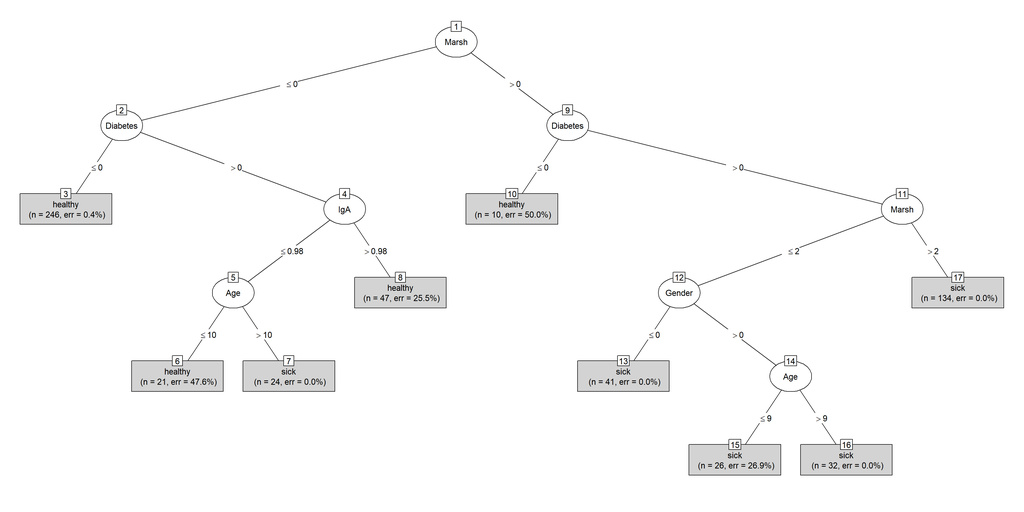

```r
plot(celiac_cost_10, type = "simple", trial = 0)
```

## K-Nearest Neighbors

KNN is a simple distance-based baseline, fitted on the normalised features using the cross-validated value of k selected above.

```r
knn_pred <- knn(train = train_norm, test = test_norm, cl = train_labels, k = best_k)

CrossTable(x = test_labels, y = knn_pred, prop.chisq = FALSE,
           dnn = c("actual", "predicted"))
```

```
##
##
##    Cell Contents
## |-------------------------|
## |                       N |
## |           N / Row Total |
## |           N / Col Total |
## |         N / Table Total |
## |-------------------------|
##
##
## Total Observations in Table:  145
##
##
##              | predicted
##       actual |   healthy |      sick | Row Total |
## -------------|-----------|-----------|-----------|
##      healthy |        58 |         2 |        60 |
##              |     0.967 |     0.033 |     0.414 |
##              |     0.967 |     0.024 |           |
##              |     0.400 |     0.014 |           |
## -------------|-----------|-----------|-----------|
##         sick |         2 |        83 |        85 |
##              |     0.024 |     0.976 |     0.586 |
##              |     0.033 |     0.976 |           |
##              |     0.014 |     0.572 |           |
## -------------|-----------|-----------|-----------|
## Column Total |        60 |        85 |       145 |
##              |     0.414 |     0.586 |           |
## -------------|-----------|-----------|-----------|
##
##
```

## Random Forest

A random forest should reduce the overfitting of a single tree and generalise better, and gives feature importance for free.

```r
rf_train <- train_raw   # already contains Disease_Diagnose alongside the predictors

rf_mod <-
  rand_forest(trees = 1000, mtry = best_mtry) %>%
  set_engine("ranger", importance = "impurity") %>%
  set_mode("classification")

set.seed(234)
rf_fit <- rf_mod %>% fit(Disease_Diagnose ~ ., data = rf_train)
```

```r
rf_testing_pred <-
  predict(rf_fit, test_raw) %>%
  bind_cols(predict(rf_fit, test_raw, type = "prob")) %>%
  bind_cols(Label = test_labels)

rf_testing_pred %>% accuracy(truth = Label, .pred_class)
```

```
## # A tibble: 1 × 3
##   .metric  .estimator .estimate
##   <chr>    <chr>          <dbl>
## 1 accuracy binary         0.938
```

### ROC curve

`Label` has levels `healthy`, `sick`. `yardstick` treats the **first** level as the event by default, so the curve is drawn against `.pred_healthy`.

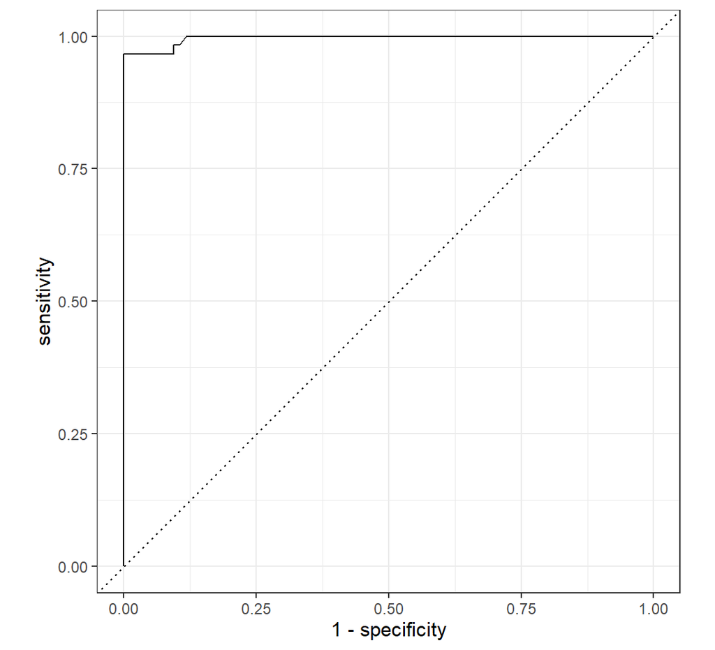

```r
rf_testing_pred %>%
  roc_curve(truth = Label, .pred_healthy) %>%
  autoplot()
```

```r
rf_testing_pred %>% roc_auc(truth = Label, .pred_healthy)
```

```
## # A tibble: 1 × 3
##   .metric .estimator .estimate
##   <chr>   <chr>          <dbl>
## 1 roc_auc binary         0.997
```

### Feature importance

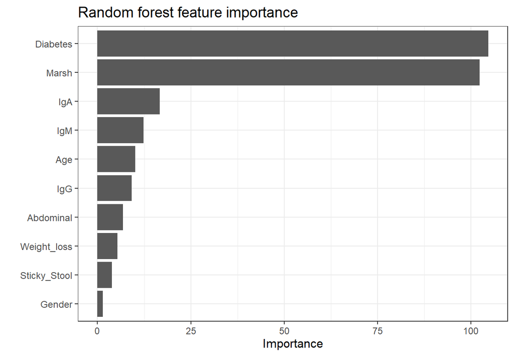

```r
vip(rf_fit, num_features = 10) +
  labs(title = "Random forest feature importance") +
  theme_bw()
```

## How Much of the Performance is `Marsh`?

The Marsh score is the histological criterion clinicians use to diagnose celiac disease. A model built on it is close to predicting the label from the label. To see what the other features contribute on their own, the same random forest is refitted with `Marsh` removed.

```r
train_no_marsh <- train_raw %>% select(-Marsh)
test_no_marsh  <- test_raw  %>% select(-Marsh)

set.seed(234)
rf_fit_no_marsh <- rf_mod %>% fit(Disease_Diagnose ~ ., data = train_no_marsh)

rf_no_marsh_pred <- predict(rf_fit_no_marsh, test_no_marsh)$.pred_class

eval_model("Random forest (no Marsh)", test_labels, rf_no_marsh_pred)
```

```
## # A tibble: 1 × 6
##   Model     Accuracy Sensitivity Specificity `False negatives` `False positives`
##   <chr>        <dbl>       <dbl>       <dbl>             <int>             <int>
## 1 Random f…    0.903       0.918       0.883                 7                 7
```

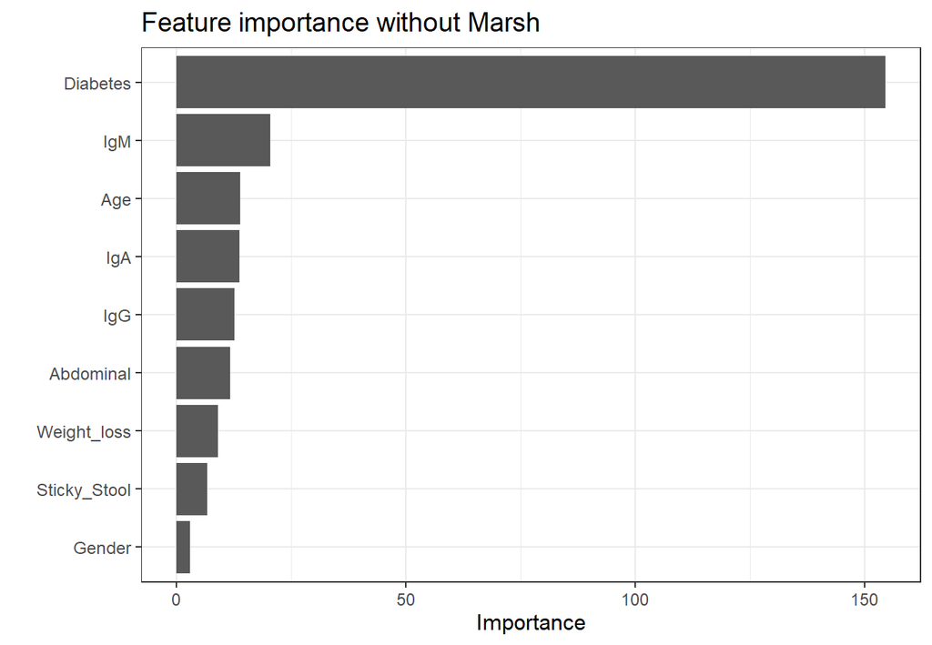

```r
vip(rf_fit_no_marsh, num_features = 9) +
  labs(title = "Feature importance without Marsh") +
  theme_bw()
```

## Model Comparison

All rows below are computed on the **same 145 test patients** using the **same ten predictors**.

```r
comparison <- bind_rows(
  eval_model("Decision tree (C5.0)",           test_labels, celiac_prediction),
  eval_model("C5.0 + boosting (10 trials)",    test_labels, celiac_boost_pred10),
  eval_model("C5.0 + boosting + cost matrix",  test_labels, celiac_cost_pred),
  eval_model(paste0("KNN (k = ", best_k, ")"), test_labels, knn_pred),
  eval_model("Random forest (1000 trees)",     test_labels, rf_testing_pred$.pred_class),
  eval_model("Random forest (no Marsh)",       test_labels, rf_no_marsh_pred)
)

comparison %>% mutate(across(c(Accuracy, Sensitivity), ~ round(.x, 3)))
```

```
## # A tibble: 6 × 6
##   Model     Accuracy Sensitivity Specificity `False negatives` `False positives`
##   <chr>        <dbl>       <dbl>       <dbl>             <int>             <int>
## 1 Decision…    0.952       0.941       0.967                 5                 2
## 2 C5.0 + b…    0.945       0.941       0.95                  5                 3
## 3 C5.0 + b…    0.972       0.976       0.967                 2                 2
## 4 KNN (k =…    0.972       0.976       0.967                 2                 2
## 5 Random f…    0.938       0.918       0.967                 7                 2
## 6 Random f…    0.903       0.918       0.883                 7                 7
```

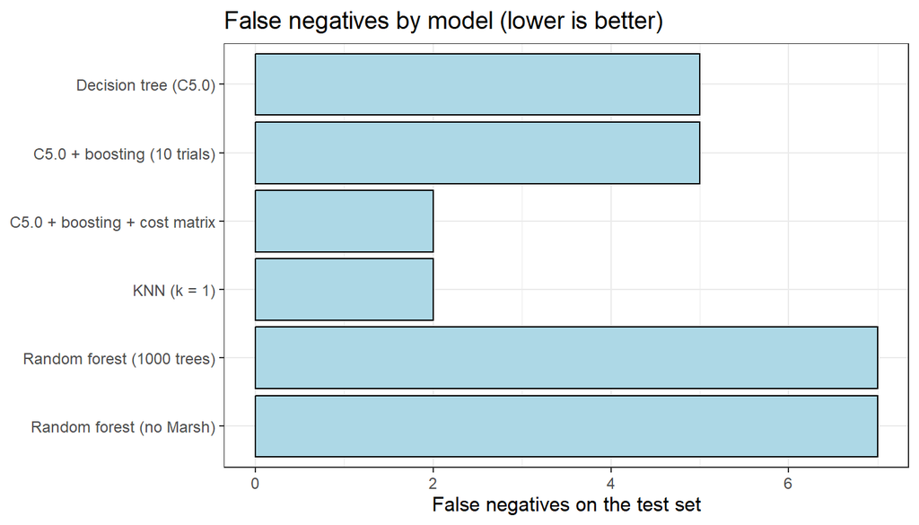

```r
comparison %>%
  mutate(Model = factor(Model, levels = rev(Model))) %>%
  ggplot(aes(x = `False negatives`, y = Model)) +
  geom_col(fill = "lightblue", color = "black") +
  labs(title = "False negatives by model (lower is better)",
       x = "False negatives on the test set", y = NULL) +
  theme_bw()
```

### Are these differences real?

A gap of one or two patients out of 145 is easy to over-read. **McNemar’s test** compares two classifiers on the *same* test cases by looking only at the cases where they disagree, which is the appropriate test for paired predictions.

```r
mcnemar_compare <- function(name_a, pred_a, name_b, pred_b) {
  tab <- table(A = pred_a == test_labels, B = pred_b == test_labels)
  p   <- mcnemar.test(tab)$p.value
  tibble(
    Comparison   = paste(name_a, "vs", name_b),
    `A only correct` = tab["TRUE", "FALSE"],
    `B only correct` = tab["FALSE", "TRUE"],
    `p value`    = round(p, 3)
  )
}

bind_rows(
  mcnemar_compare("Cost-sensitive C5.0", celiac_cost_pred, "Random forest", rf_testing_pred$.pred_class),
  mcnemar_compare("Cost-sensitive C5.0", celiac_cost_pred, "Decision tree",  celiac_prediction),
  mcnemar_compare("Random forest",       rf_testing_pred$.pred_class, "KNN", knn_pred)
)
```

```
## # A tibble: 3 × 4
##   Comparison                         `A only correct` `B only correct` `p value`
##   <chr>                                         <int>            <int>     <dbl>
## 1 Cost-sensitive C5.0 vs Random for…                5                0     0.074
## 2 Cost-sensitive C5.0 vs Decision t…                3                0     0.248
## 3 Random forest vs KNN                              0                5     0.074
```

The discordant counts are small, so these comparisons have very little statistical power. Read the p-values as *“this test set cannot distinguish these models”* rather than as evidence they perform equally — with 145 patients, only a large difference would reach significance. The cross-validated estimates earlier in the report, averaged over 50 resamples, are the more reliable basis for choosing between them.

## What Happens at Realistic Prevalence

Every accuracy figure above was measured on a dataset that is **50% celiac by construction**. Real celiac prevalence in the general population is roughly **1%** (Singh et al., *Clin Gastroenterol Hepatol* 2018, pooled seroprevalence ~1.4%, biopsy-confirmed ~0.7%). That gap matters more than it first appears.

Sensitivity and specificity are properties of the classifier and do not depend on prevalence. **Precision — the positive predictive value — does.** So the models can be projected onto a realistic population directly from their sensitivity and specificity, without refitting anything:

$$\text{PPV} = \frac{\text{sens} \times
p}{\text{sens} \times p + (1-\text{spec}) \times (1-p)}
\qquad
\text{NPV} = \frac{\text{spec} \times (1-p)}{\text{spec} \times (1-p) +
(1-\text{sens}) \times p}$$

```r
ppv_at <- function(sens, spec, p) (sens * p) / (sens * p + (1 - spec) * (1 - p))
npv_at <- function(sens, spec, p) (spec * (1 - p)) / (spec * (1 - p) + (1 - sens) * p)
```

Sanity check — at the dataset’s own prevalence the formula must reproduce the observed precision:

```r
best     <- comparison %>% filter(Model == "C5.0 + boosting + cost matrix")
cm_best  <- confusion(test_labels, celiac_cost_pred)
obs_prev <- mean(test_labels == "sick")

round(c(
  from_formula = ppv_at(best$Sensitivity, best$Specificity, obs_prev),
  from_matrix  = cm_best["sick", "sick"] / sum(cm_best["sick", ])
), 4)
```

```
## from_formula  from_matrix
##       0.9765       0.9765
```

### Predictive value across prevalence

```r
prevalences <- c(0.005, 0.01, 0.05, 0.50)

comparison %>%
  filter(Model %in% c("C5.0 + boosting + cost matrix", "Random forest (1000 trees)")) %>%
  rowwise() %>%
  reframe(
    Model, Prevalence = prevalences,
    PPV = ppv_at(Sensitivity, Specificity, prevalences),
    NPV = npv_at(Sensitivity, Specificity, prevalences)
  ) %>%
  mutate(across(c(PPV, NPV), ~ round(.x, 3)),
         Prevalence = scales::percent(Prevalence, accuracy = 0.1))
```

```
## # A tibble: 8 × 4
##   Model                         Prevalence   PPV   NPV
##   <chr>                         <chr>      <dbl> <dbl>
## 1 C5.0 + boosting + cost matrix 0.5%       0.128 1
## 2 C5.0 + boosting + cost matrix 1.0%       0.228 1
## 3 C5.0 + boosting + cost matrix 5.0%       0.607 0.999
## 4 C5.0 + boosting + cost matrix 50.0%      0.967 0.976
## 5 Random forest (1000 trees)    0.5%       0.122 1
## 6 Random forest (1000 trees)    1.0%       0.218 0.999
## 7 Random forest (1000 trees)    5.0%       0.592 0.996
## 8 Random forest (1000 trees)    50.0%      0.965 0.921
```

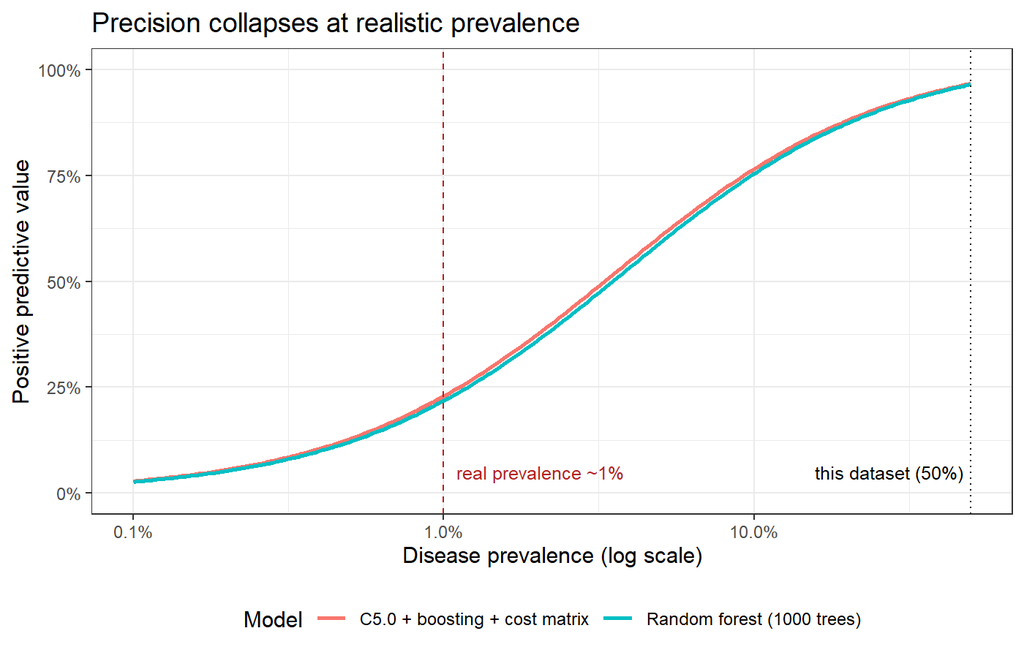

```r
curve_df <- comparison %>%
  filter(Model %in% c("C5.0 + boosting + cost matrix", "Random forest (1000 trees)")) %>%
  rowwise() %>%
  reframe(Model, p = 10^seq(-3, log10(0.5), length.out = 200)) %>%
  left_join(comparison %>% select(Model, Sensitivity, Specificity), by = "Model") %>%
  mutate(PPV = ppv_at(Sensitivity, Specificity, p))

ggplot(curve_df, aes(x = p, y = PPV, colour = Model)) +
  geom_line(linewidth = 0.9) +
  geom_vline(xintercept = 0.01, linetype = "dashed", colour = "firebrick") +
  geom_vline(xintercept = 0.50, linetype = "dotted") +
  annotate("text", x = 0.011, y = 0.05, label = "real prevalence ~1%",
           hjust = 0, size = 3.2, colour = "firebrick") +
  annotate("text", x = 0.5, y = 0.05, label = "this dataset (50%)",
           hjust = 1.05, size = 3.2) +
  scale_x_log10(labels = scales::percent) +
  scale_y_continuous(labels = scales::percent, limits = c(0, 1)) +
  labs(title = "Precision collapses at realistic prevalence",
       x = "Disease prevalence (log scale)", y = "Positive predictive value") +
  theme_bw() +
  theme(legend.position = "bottom")
```

### Why accuracy is the wrong headline

At 1% prevalence, a model that simply predicts “healthy” for everyone achieves **99% accuracy** — better than anything reported above — while finding zero cases. Accuracy on a balanced sample says almost nothing about performance as a screening tool.

The honest reading of these models is:

- **NPV stays near 100%.** A negative result is highly trustworthy.
- **PPV falls sharply.** At 1% prevalence most positive flags would be false alarms.

That combination describes a **rule-out screening test**, not a diagnostic one: useful for deciding who does *not* need a biopsy, not for confirming who has celiac disease. Given that biopsy is the confirmatory step anyway, that is a reasonable role — but it is a much narrower claim than “97.2% accurate”.

## Conclusions

- **The cost-sensitive boosted tree and tuned KNN tie for best**, both at 97.2% accuracy with 2 false negatives and 2 false positives. Encoding the clinical asymmetry into C5.0 training works — it takes false negatives from 5 to 2 while *improving* accuracy.
- **No difference between the top models is statistically significant.** McNemar’s test on the paired predictions gives p ≈ 0.07 at best. With 145 patients, this test set cannot separate them; the cross-validated estimates over 50 resamples are the more trustworthy comparison.
- The random forest did **not** come out ahead (93.8%, 7 false negatives). An earlier version of this analysis concluded that it did — an artefact of scoring each model on a different train/test split and a different feature set. Once the comparison is fair, the advantage disappears.
- **The headline accuracy is inflated by `Marsh`.** Dropping it costs the forest about three and a half points of accuracy (93.8% → 90.3%) and more than triples its false positives (2 → 7). Notably, sensitivity is *unchanged* at 0.918 — the damage is entirely to specificity. Without the histological score the model still finds the same cases, but flags many more healthy patients along with them.
- **At realistic prevalence these models are rule-out tools, not diagnostics.** Precision falls from ~97% on this balanced sample to roughly **23% at 1% prevalence**, while NPV stays at ~100%. A negative result is trustworthy; a positive one mostly is not.

Several of these conclusions reverse what the first version of this report claimed, and every reversal came from fixing methodology rather than changing a model: sharing one split and feature set, correcting the orientation of the cost matrix, tuning by cross-validation instead of by hand, and testing whether the differences were real. Notably, the earlier “zero false negatives” result did not survive proper tuning.

## Next Steps

- Nested cross-validation, so the performance estimate is not conditioned on a single outer split
- A single explicit objective (e.g. expected cost, or sensitivity at fixed specificity) used to select every hyperparameter, resolving the inconsistency noted above
- Decision-threshold analysis on predicted probabilities, replacing the discrete cost ratio with a full precision–recall trade-off curve
- One-hot encode `Diarrhoea` and `Short_Stature` so they can be used without breaking KNN
- Investigate whether different symptoms correlate with different celiac subtypes
- Unsupervised clustering, to see whether the data splits into more than two groups without the labels
- External validation on an independent dataset